# Monocle3-Cicero

Lorenzo Martini

2023-05-30

# Monocle3 and Cicero processing of 10X multimodal PBMC dataset

N.B. This may require the installation of local libraries. Please check the README file of the project for a list of required packages

Here we present all the steps to properly analyze the multimodal dataset with the Cole Trapnell Lab tools.

DATA available at: https://www.10xgenomics.com/resources/datasets/10-k-human-pbm-cs-multiome-v-1-0-chromium-controller-1-standard-2-0-0

Filtered feature barcode matrix MEX (DIR)

Filtered feature barcode matrix (HDF5)

ATAC peak locations (BED)

ATAC Per fragment information file (TSV.GZ)

ATAC Per fragment information index (TSV.GZ index)

One needs to load all the necessary packages listed below.

```r
library(monocle3)
library(cicero)
library(Matrix)
library(dplyr)
```

```r
library(ggplot2)
library(garnett)
library(aricode)
library(org.Hs.eg.db)
#library(SeuratDisk)
```

First of all, we load the data. In this case the data matrix is only one with both data type, meaning a matrix with the cells as column and the rows are first the genes and then the peaks. Therefore, one needs to divide the matrix in its two parts, because Monocle3 is not able to properly differentiate the two.

```r
#loading of the data
matrix <- readMM("../DATA/filtered_feature_bc_matrix/matrix.mtx")
cells <- read.table("../DATA/filtered_feature_bc_matrix/barcodes.tsv")
features <- read.delim("../DATA/filtered_feature_bc_matrix/features.tsv", header=FALSE)

#division of the fetures between genes and peaks
genes <- features[features$V3 == "Gene Expression",]
colnames(genes)[2] <- "gene_short_name"
peaks <- features[features$V3 == "Peaks",]

row.names(matrix) <- features$V2
colnames(matrix) <- cells$V1

#creation of the two matrices, accordingly to the features
RNA_matrix <- matrix[genes$gene_short_name,]
ATAC_matrix <- matrix[peaks$V2,]
```

# Gene Expression data processing and analysis

We start with the Gene Expression data.

The processing ends with the visualiztion of the clustered cells. The main parameter one can fine-tune is the resolution. Here the value is the one advised for datasets this large, but one can change if it appears result in too many or too few clusters.

```
## No trajectory to plot. Has learn_graph() been called yet?
```

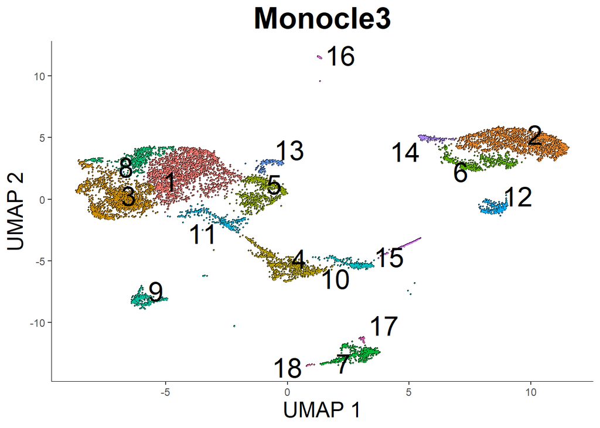

```r
#Creation of the CDS object
CDS_RNA <- new_cell_data_set(RNA_matrix)
#adding gene names as a metadata for rows, useful for later functions
rowData(CDS_RNA)$gene_short_name <- genes$gene_short_name
CDS_RNA <- detect_genes(CDS_RNA)
CDS_RNA <- estimate_size_factors(CDS_RNA)
#preprocessing consisting in normalization, scaling, and dimansional reduction (both LSI and PCA)
CDS_RNA <- preprocess_cds(CDS_RNA, method = "LSI")
CDS_RNA <- preprocess_cds(CDS_RNA, method = "PCA")
#non-linear dimensional reduction UMAP, to visualize the cells in 2D
CDS_RNA <- reduce_dimension(CDS_RNA, reduction_method = 'UMAP',
                              preprocess_method = "PCA")
#clustering of the cells, based on the UMAP
CDS_RNA <- cluster_cells(CDS_RNA, resolution=0.5e-3)
#final plotting
plot_cells(CDS_RNA,reduction_method = 'UMAP', group_label_size = 8)  + labs(title = "Monocle3") + theme(plot.title = element_text(hjust = 0.5, size = 25, face = "bold"),axis.title = element_text(size = 18))
ggsave(path = "../TMPResults/IMAGES/", filename = "RNA_clustering_Monocle.pdf", width = 854, height = 480, units= "px",scale = 3.5)
```

After processing, one can perform differential expression analysis, to understand which genes identifies the cell clusters.

```r
marker_test_res_rna <- top_markers(CDS_RNA)
head(marker_test_res_rna)
```

```r
#from all the DE genes, select the top ones for each cluster
top_specific_markers_rna <- marker_test_res_rna %>%
                    filter(fraction_expressing >= 0.10) %>%
                    filter(specificity >= 0.15) %>%
                    group_by(cell_group) %>%
                    top_n(1, pseudo_R2)
#plot them and their expression level on the clusters
top_specific_marker_ids <- unique(top_specific_markers_rna %>% pull(gene_id))
plot_genes_by_group(CDS_RNA,
                    top_specific_marker_ids,
                    group_cells_by="cluster",
                    ordering_type="maximal_on_diag") +  guide_legend(title = "")

ggsave(path = "../TMPResults/IMAGES/", filename = "RNA_DE_Monocle.pdf", width = 720, height = 900, units= "px",scale = 3.5 )
```

# ScATAC-seq data separate analysis

The same workflow is necessary to process the epigenetic data. One needs to remeber to binarize the matrix, before going on. Again the final result is the visulaiztion of the cells divided in clusters, which should be, in some way, similar to the previous one.

```
## No trajectory to plot. Has learn_graph() been called yet?
```

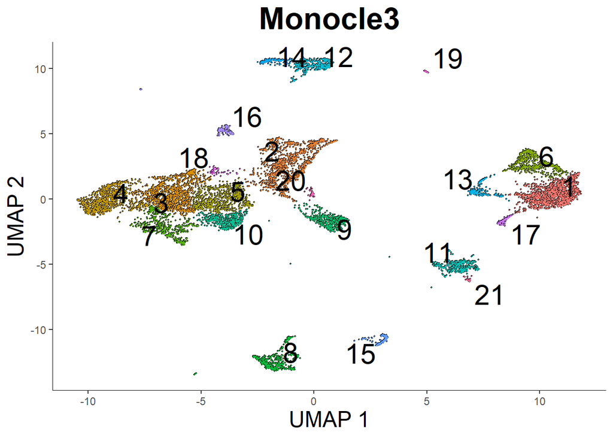

```r
#binarization of the matrix
ATAC_matrix@x[ATAC_matrix@x > 0] <- 1
#Creation of the CDS object for the ATAC data
CDS_ATAC <- new_cell_data_set(ATAC_matrix)
rowData(CDS_ATAC)$gene_short_name <- peaks$V2
#the process and function are totally analogous to  before
CDS_ATAC <- detect_genes(CDS_ATAC)
  CDS_ATAC <- estimate_size_factors(CDS_ATAC)
  CDS_ATAC <- preprocess_cds(CDS_ATAC, method = "LSI")
  CDS_ATAC <- preprocess_cds(CDS_ATAC, method = "PCA")
  CDS_ATAC <- reduce_dimension(CDS_ATAC, reduction_method = 'UMAP',
                              preprocess_method = "LSI")
  CDS_ATAC <- cluster_cells(CDS_ATAC, resolution=0.7e-3)
#plot the results based on ATAC data alone
plot_cells(CDS_ATAC,reduction_method = 'UMAP', group_label_size = 8)  + labs(title = "Monocle3") + theme(plot.title = element_text(hjust = 0.5, size = 25, face = "bold"), axis.title = element_text(size = 18))
ggsave(path = "../TMPResults/IMAGES/", filename = "ATAC_clustering_Monocle.pdf", width = 854, height = 480, units= "px",scale = 3.5 )
```

Agein one can perform differential analysis, to understand which peaks characterize the clusters. In this case, the process tends to be more lengthy and, moreover, the results are not particularly satisfactory. Therefore, it is not always particularly useful to perform.

```r
marker_test_res_atac <- top_markers(CDS_ATAC)
head(marker_test_res_atac)
```

```r
top_specific_markers_atac <- marker_test_res_atac %>%
                    filter(fraction_expressing >= 0.10) %>%
                    filter(specificity >= 0.15) %>%
                    group_by(cell_group) %>%
                    top_n(1, pseudo_R2)
top_specific_marker_ids_atac <- unique(top_specific_markers_atac %>% pull(gene_id))
plot_genes_by_group(CDS_ATAC,
                    top_specific_marker_ids_atac,
                    group_cells_by="cluster",
                    ordering_type="maximal_on_diag")
ggsave(path = "../TMPResults/IMAGES/", filename = "ATAC_DE_Monocle.pdf", width = 720, height = 900, units= "px",scale = 3.5 )
```

It is useful to save the objects

# Cell type classification with Garnett

Now, one needs to classify the cells. The most direct way to do it when working with Monocle is to employ Garnett, since it has a direct integration. In this case, since we are working with a PBMC sample, we can use the trained classifier directly provided by Garnett from here: https://cole-trapnell-lab.github.io/garnett/classifiers/

```r
#load the classifier
pbmc_classifier <- readRDS("../DATA/garnett/hsPBMC_20191017.RDS")
#classify the dataset with that, employing the gene expression data
CDS_RNA <- classify_cells(CDS_RNA, pbmc_classifier,
                           db = org.Hs.eg.db,
                           cluster_extend = TRUE,
                           cds_gene_id_type = "SYMBOL")
```

```
## No trajectory to plot. Has learn_graph() been called yet?
```

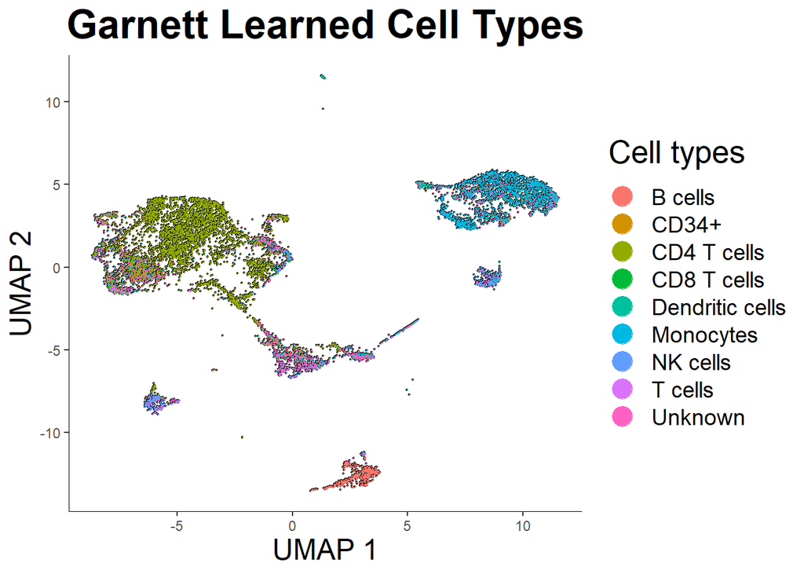

```r
#plot the classified cells
plot_cells(CDS_RNA,
           color_cells_by="cluster_ext_type", label_cell_groups = FALSE, )  + ggtitle("Garnett Learned Cell Types") + theme(plot.title = element_text(hjust = 0.5, size = 25, face = "bold"),axis.title = element_text(size = 18)) + guides(colour = guide_legend(override.aes = list(size=6), title = "Cell types", title.theme = element_text(size = 20), label.theme = element_text(size = 14)) )
ggsave(path = "../TMPResults/IMAGES/", filename = "RNA_classification_Garnett.pdf", width = 854, height = 480, units= "px",scale = 3.5 )
```

```
## No trajectory to plot. Has learn_graph() been called yet?
```

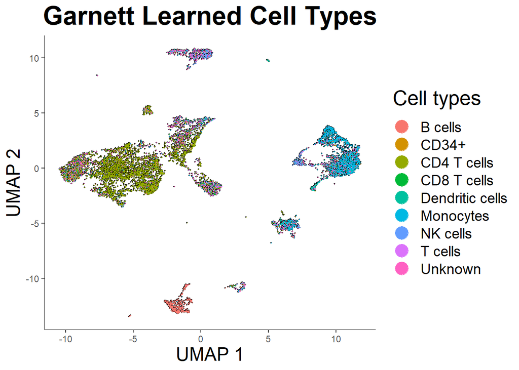

```r
cluster_ext_type <- as.data.frame(CDS_RNA@colData@listData[["cluster_ext_type"]])
colnames(cluster_ext_type) <- "CLASS"
CDS_ATAC@colData@listData[["cluster_ext_type"]] <- cluster_ext_type$CLASS
plot_cells(CDS_ATAC,
           color_cells_by="cluster_ext_type", label_cell_groups = FALSE, )  + ggtitle("Garnett Learned Cell Types") + theme(plot.title = element_text(hjust = 0.5, size = 25, face = "bold"),axis.title = element_text(size = 18)) + guides(colour = guide_legend(override.aes = list(size=6), title = "Cell types", title.theme = element_text(size = 20), label.theme = element_text(size = 14)) )
ggsave(path = "../TMPResults/IMAGES/", filename = "ATAC_classification_Garnett.pdf", width = 854, height = 480, units= "px",scale = 3.5 )
```

# Classifications comparison

With all the previous processes, one obtains various classifications of the cells. To understand how much the are similar between each other, one can employ information theory concepts like ARI and AMI. In particular we want to understand if the clustering obtained from the processing of the data is consistent with the cell-type classification.

```r
MON_class_RNA <- as.data.frame(CDS_RNA@clusters@listData[["UMAP"]][["clusters"]])
colnames(MON_class_RNA) <- "CLASS"
MON_class_RNA$CLASS <- as.factor(MON_class_RNA$CLASS)
#levels(MON_class_RNA$CLASS) <- paste0(levels(MON_class_RNA$CLASS), "_R")

MON_class_ATAC <- as.data.frame(CDS_ATAC@clusters@listData[["UMAP"]][["clusters"]])
colnames(MON_class_ATAC) <- "CLASS"
MON_class_ATAC$CLASS <- as.factor(MON_class_ATAC$CLASS)
#levels(MON_class_ATAC$CLASS) <- paste0(levels(MON_class_ATAC$CLASS), "_A")

cluster_ext_type <- as.data.frame(CDS_RNA@colData@listData[["cluster_ext_type"]])
colnames(cluster_ext_type) <- "CLASS"
```

```
## [1] "RNA vs ATAC"
```

```
## [1] "ARI: 0.411"
```

```
## [1] "AMI: 0.559"
```

```
## [1] "Cell-types vs RNA"
```

```
## [1] "ARI: 0.288"
```

```
## [1] "AMI: 0.329"
```

```
## [1] "Cell-types vs ATAC"
```

```
## [1] "ARI: 0.174"
```

```
## [1] "AMI: 0.274"
```

```
## No trajectory to plot. Has learn_graph() been called yet?
```

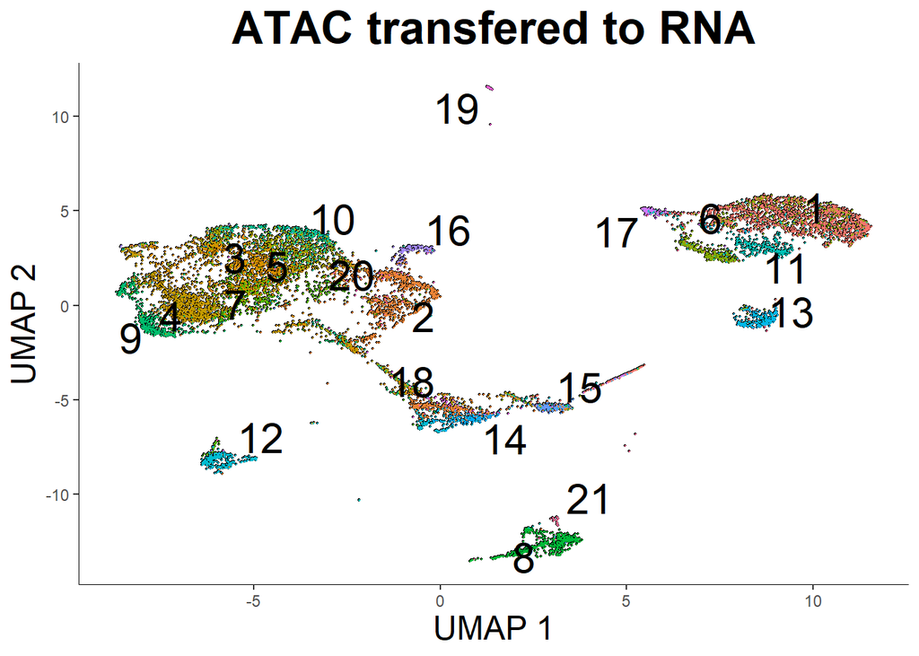

```
## No trajectory to plot. Has learn_graph() been called yet?
```

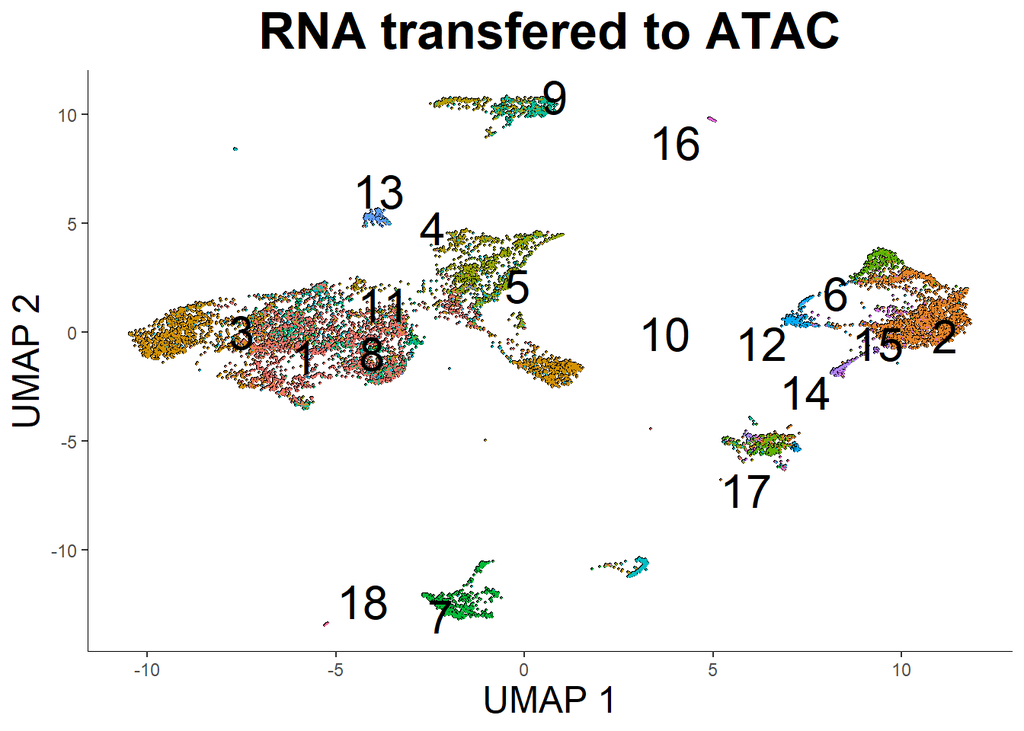

```r
CDS_RNA@colData@listData[["MON_class_ATAC"]] <- MON_class_ATAC$CLASS
CDS_ATAC@colData@listData[["MON_class_RNA"]] <- MON_class_RNA$CLASS

plot_cells(CDS_RNA,reduction_method = 'UMAP', group_label_size = 8, color_cells_by = "MON_class_ATAC", label_groups_by_cluster = FALSE)  + labs(title = "ATAC transfered to RNA") + theme(plot.title = element_text(hjust = 0.5, size = 25, face = "bold"),axis.title = element_text(size = 18))
ggsave(path = "../TMPResults/IMAGES/", filename = "ATAC_to_RNA_Monocle.pdf", width = 854, height = 480, units= "px",scale = 3.5 )


plot_cells(CDS_ATAC,reduction_method = 'UMAP', group_label_size = 8, color_cells_by =  "MON_class_RNA", label_groups_by_cluster = FALSE)  + labs(title = "RNA transfered to ATAC") + theme(plot.title = element_text(hjust = 0.5, size = 25,face = "bold"),axis.title = element_text(size = 18))
ggsave(path = "../TMPResults/IMAGES/", filename = "RNA_to_ATAC_Monocle.pdf", width = 854, height = 480, units= "px",scale = 3.5 )
```

# Gene Activity Matrix (GAM)

Next is the Gene Activity Matrix calculation from ATAC data.

The gene activity is a medium between gene expression and chromatin accessibility. It describes the acessibility of the genetic regions inside the cells of the datasets. There are different ways to create it, here we expose how to do it with Cicero.

Preliminary, one needs to aggregate the CDS, as shown below.

```r
umap_coords <- reducedDims(CDS_ATAC)$UMAP
cicero_cds <- make_cicero_cds(CDS_ATAC, reduced_coordinates = umap_coords)
```

Then, employing a geneome reference, one can calculate the connections, meaning the co-accessibility scores of the peaks in the dataset. The co-accessbility calculation is very lennghty and compuattionally heavy, so we suggest to perform it consciously.

```r
genome_ref = read.table("../DATA/genomes/hg38/hg38.p13.chrom.sizes.txt")
genome_ref <- genome_ref[1:24,]
hg38 <- genome_ref[1:24,]
#hg38$V1 <- as.character.factor(hg38$V1)
hg38 <- Seqinfo(hg38$V1, seqlengths= hg38$V2)
hg38@genome[] <- "hg38"
```

```r
conns <- run_cicero(cicero_cds, genome_ref, sample_num = 2)
```

After that, one needs to load a gene annotation file, containing all the genomic coordinates of the genes of the given genome. With that Cicero labels all the peaks that overlap the first base of the genes as promoters.

```r
gene_anno <- rtracklayer::readGFF("../DATA/genomes/hg38/GCF_000001405.39_GRCh38.p13_genomic.gtf.gz")
chr2acc <- read.csv("../DATA/genomes/hg38/chr2acc.txt", sep = "\t")
gene_anno <- gene_anno[gene_anno$seqid %in% chr2acc$Accession.version,]
gene_anno$seqid <- as.factor(as.character(gene_anno$seqid))
levels(gene_anno$seqid) <- chr2acc$X.Chromosome
gene_anno$seqid <- paste0("chr", gene_anno$seqid)


gene_anno$chromosome <- gene_anno$seqid
#gene_anno$chromosome <- paste0("chr", gene_anno$seqid)
gene_anno$gene <- gene_anno$gene_id
gene_anno$transcript <- gene_anno$transcript_id
gene_anno$symbol <- gene_anno$gene



pos <- subset(gene_anno, strand == "+")
pos <- pos[order(pos$start),]
# remove all but the first exons per transcript
pos <- pos[!duplicated(pos$transcript),]
# make a 1 base pair marker of the TSS
pos$end <- pos$start + 1

neg <- subset(gene_anno, strand == "-")
neg <- neg[order(neg$start, decreasing = TRUE),]
# remove all but the first exons per transcript
neg <- neg[!duplicated(neg$transcript),]
neg$start <- neg$end - 1

gene_annotation_sub <- rbind(pos, neg)

# Make a subset of the TSS annotation columns containing just the coordinates
# and the gene name
gene_annotation_sub <- gene_annotation_sub[,c("chromosome", "start", "end", "symbol")]

# Rename the gene symbol column to "gene"
names(gene_annotation_sub)[4] <- "gene"

CDS_ATAC <- annotate_cds_by_site(CDS_ATAC, gene_annotation_sub)
```

```r
con_val <- conns[conns$coaccess > 0,]
con_val <- con_val[!is.na(con_val$coaccess),]
coaccess <- signif(mean(con_val$coaccess), digits = 2)
unnorm_ga <- build_gene_activity_matrix(CDS_ATAC, conns, coaccess_cutoff = coaccess)
unnorm_ga <- unnorm_ga[!Matrix::rowSums(unnorm_ga) == 0,
                       !Matrix::colSums(unnorm_ga) == 0]
num_genes <- pData(CDS_ATAC)$num_genes_expressed
names(num_genes) <- row.names(pData(CDS_ATAC))

cicero_gene_activities <- normalize_gene_activities(unnorm_ga, num_genes)
```

After the GAM creation, one can process it, treating it like a gene expression matrix.

```r
cicero_cell <- colnames(cicero_gene_activities)
lenght1 <- length(cicero_cell)
cicero_gene <- row.names(cicero_gene_activities)
lenght2 <- length(cicero_gene)
c_c <- matrix(cicero_cell, nrow = lenght1, dimnames = list(cicero_cell,c("Cells")))
c_g<- matrix(cicero_gene, nrow = lenght2, dimnames = list(cicero_gene,c("gene_short_name")))


## processing GAM with Cicero
CDS_ACTIVITY <-  suppressWarnings(new_cell_data_set(cicero_gene_activities, cell_metadata = c_c, gene_metadata = c_g))
```

```
## No trajectory to plot. Has learn_graph() been called yet?
```

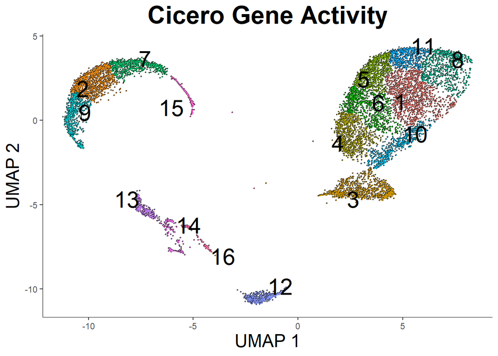

```r
CDS_ACTIVITY <- detect_genes(CDS_ACTIVITY)
CDS_ACTIVITY <- estimate_size_factors(CDS_ACTIVITY)
CDS_ACTIVITY <- preprocess_cds(CDS_ACTIVITY, method = "PCA")

CDS_ACTIVITY <- reduce_dimension(CDS_ACTIVITY, reduction_method = 'UMAP',
                               preprocess_method = "PCA")
CDS_ACTIVITY = cluster_cells(CDS_ACTIVITY, resolution=1e-3)

plot_cells(CDS_ACTIVITY,reduction_method = 'UMAP', group_label_size = 8)  + labs(title = "Cicero Gene Activity") + theme(plot.title = element_text(hjust = 0.5, size = 25, face = "bold"),axis.title = element_text(size = 18))
ggsave(path = "../TMPResults/IMAGES/", filename = "Activity_clustering_Cicero.pdf", width = 854, height = 480, units= "px",scale = 3.5 )
```

It is useful to plot the cell-types labels (or the gene expression-derived clusters), to ensure that the results are, in some sort, coherent with the previous ones.

```
## No trajectory to plot. Has learn_graph() been called yet?
```

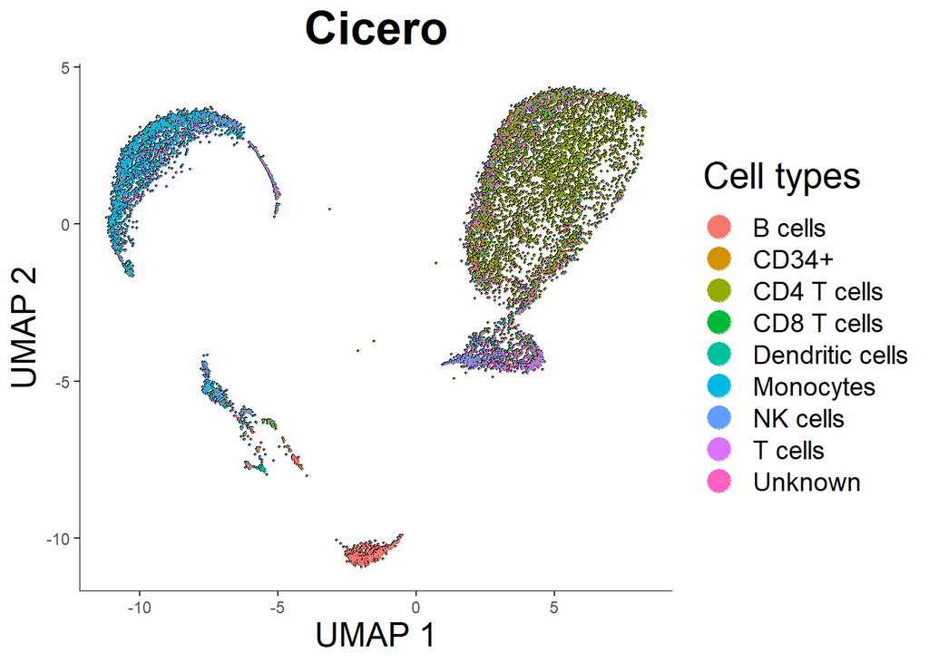

```r
#insert the classifications inside the CDS
CDS_ACTIVITY@colData@listData[["MON_class_RNA"]] <- MON_class_RNA$CLASS
CDS_ACTIVITY@colData@listData[["cluster_ext_type"]] <- cluster_ext_type$CLASS
plot_cells(CDS_ACTIVITY,
           color_cells_by="cluster_ext_type", label_cell_groups = FALSE, )  + ggtitle("Cicero") + theme(plot.title = element_text(hjust = 0.5, size = 25, face = "bold"),axis.title = element_text(size = 18)) + guides(colour = guide_legend(override.aes = list(size=6), title = "Cell types", title.theme = element_text(size = 20), label.theme = element_text(size = 14)) )
ggsave(path = "../TMPResults/IMAGES/", filename = "Activity_celltype_Cicero.pdf", width = 854, height = 480, units= "px",scale = 3.5 )
```

# Comparative Differential analysis

The comparative Differential analysis consists in performing differenatial activity analysis on the GAM data to understand if the genes that are related to specific cell type (or cluster), at the transcriptomic level (i.e., DE genes and marker genes), appear to be also differentially active, meaning they are specific also at the epigenomic level. To do so, one takes the processed GAM, and performs the differential analysis, based on diffrent classifications, including: GAM derived clustering cell-type classification scRNA-seq derived clustering From the results, one looks for the wanted genes, to look if they are related to the same group of cells.

In this way one makes a cross-modality assessment of the genes

First, we create the list of the genes we want to investigate the accessibility.

```r
marker_genes = c("CD34", "THY1", "ENG", "KIT", "PROM1","NCAM1", "FCGR3A","CD14", "FCGR1A", "CD68", "S100A12","CD19", "MS4A1", "CD79A","CD4", "FOXP3", "IL2RA", "IL7R","CD8A", "CD8B","IL3RA", "CD1C", "BATF3", "THBD", "CD209")
marker_activity_clust <- top_markers(CDS_ACTIVITY)
marker_activity_clust_in_marker_genes <- marker_activity_clust[marker_activity_clust$gene_short_name %in% marker_genes,]
marker_activity_clust_in_marker_genes
```

```r
marker_expression_clust <- top_markers(CDS_ACTIVITY, group_cells_by = "MON_class_RNA")
marker_expression_clust_in_marker_genes <- marker_expression_clust[marker_expression_clust$gene_short_name %in% marker_genes,]
marker_expression_clust_in_marker_genes
```

```r
marker_activity_cell_type <- top_markers(CDS_ACTIVITY, group_cells_by = "cluster_ext_type")
marker_activity_cell_type_in_marker_genes <- marker_activity_cell_type[marker_activity_cell_type$gene_short_name %in% marker_genes,]

marker_activity_cell_type_in_marker_genes
```